# Assignment 2

Abhinandan Saha

### Due Friday, February 10, 11:59 PM CT

### Aims

- Read ggplot2 code examples for making graphics and describe what different commands do;
- Practice using `ggplot2` commands on new data to mimic examples from lecture.

### Notes

- This file assumes that your course home directory contains a folder named `data`, a folder named `homework`, and a folder within `homework` named `hw02`, and that you have installed the **tidyverse** package.
  - If you did not name your directories this way, you might need to change some names to match your naming scheme (see Preliminaries section below for more on this)

### Data

##### Lake Monona

Data in *lake-monona-winters-2022.csv* is similar to that in the Lake Mendota data set from lecture, but contains freeze durations in Lake Monona, **and not from Lake Mendota**. There is one row from each winter from 1855–56 through 2021–22.

Variables in the data set are:

- winter — a string such as “1855-56” which specifies the winter
- year1 — the first year of the winter
- periods — the number of periods of consecutive days where the surface of Lake Monona was closed by 50% or more of ice.
- duration — the total number of days during the winter that 50% or more of the lake surface is frozen (closed by ice)
- first_freeze — the first date the lake is closed during the winter
- last_thaw — the date of the last thaw during the winter
- decade — the decade of the first winter
- period50 — a 50-year period of time
- ff_x — the number of days after June 30 of the first freeze
- ff_cat — a categorical variable of the half-month of the first freeze

*Note: lecture notes had a different name than `ff_x` for counting the days after June 30.*

### Preliminaries

- If you do not already have them, create the following sub-directories in your course directory.
  - `data`
  - `homework`
  - `homework/hw02` — this means create `hw02` inside of `homework`

- Directories
  - COURSE/homework/
  - COURSE/homework/hw02/
  - COURSE/data/
- Files
  - COURSE/homework/hw02/hw02.Rmd
  - COURSE/data/lake-monona-winters-2022.csv
- Download the file `lake-monona-winters-2022.csv` and place it in the `data` directory.
- Download the file `hw02.Rmd` and place into the `homework/hw02` directory.
- Navigate to the `homework/hw02` directory and set it to be your working directory.
- Open the `hw02.Rmd` document and answer the questions. You will need to complete chunks to solve the problems. Some problems require written responses in addition to code.

### Problems

1. The following code makes a histogram of the `duration` variable in the Lake Monona data set.

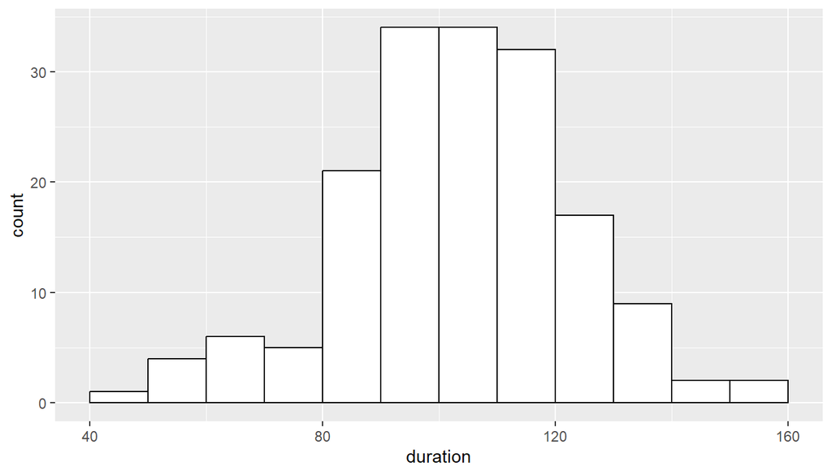

```r
ggplot(monona, aes(x=duration)) +
  geom_histogram(boundary = 0, binwidth = 10,
                 color = "black", fill = "white")
```

In approximately how many winters was the total duration where Lake Monona was at least 50% covered with ice between 40 to 70 days?

### Response

2. Modify the code below so that:
- one of the bin boundaries is at 70 days
- the width of each bin is 5 days
- the fill color is “cyan”
- the color outlining the bars is “forestgreen”
- the x label says “Days Closed with Ice”
- the y label says “Total”
- there is a title with words of your choosing that describe the figure

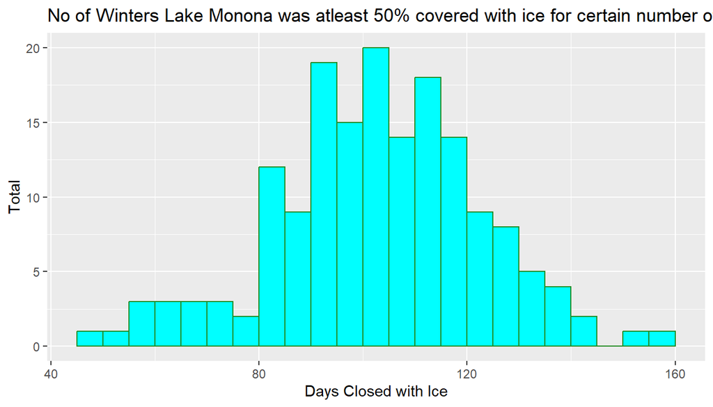

```r
ggplot(monona, aes(x = duration)) +
  geom_histogram(boundary = 70, binwidth = 5,
                 fill = "cyan",
                 color = "forestgreen") +
    ggtitle("No of Winters Lake Monona was atleast 50% covered with ice for certain number of days") +
  xlab("Days Closed with Ice") +
  ylab("Total")
```

3. Code in the next chunk makes a scatter plot that shows how the variable `duration` changes with time (using `year1`).

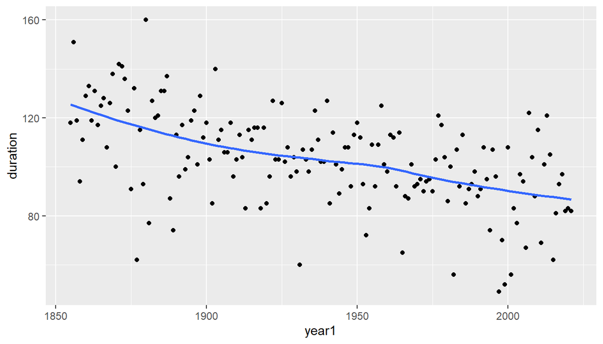

```r
ggplot(monona, aes(x = year1, y = duration)) +
  geom_point() +
  geom_smooth(se=FALSE)
```

- What does the line of code `geom_smooth(se=FALSE)` do? (Explain what it adds to the plot; you don’t need to explain details of the method.)

### Response

As we observe, the scatter plots the data values showing the correspondence between duration and year1 on the graph. The line of code adds a smooth curve showing the overall trend of correspondence of the data. It reduces the noise of the data greatly and give the average or expected duration for the given year.

- Describe the pattern of the curve.

### Response

As we observe, the slope of the curve is negative and thus the general trend of data is decreasing, i.e. the average duration for which the lake has been atleast 50% covered with ice has been decreasing.

- How long was Lake Monona closed with closed with ice in a typical year near 1875 (i.e., what is the approximate value of the smooth curve around 1875)?

### Response

In a typical year near 1875, the lake was on average closed for around 118 to 120 days.

- How long was Lake Monona closed with ice in a typical year near 2000 (i.e., what is the approximate value of the smooth curve around 2000)?

### Response

In a typical year near 2000, the lake was on average closed for around 90 days.

4. Modify the code in the following chunk so that:
- There is a box plot displaying the distribution of the days Lake Monona is closed by ice
- The box plot fill color is “yellow”
- The color of the edges of the box plot is “magenta”
- There is a more descriptive y-axis label
- There is an informative plot title

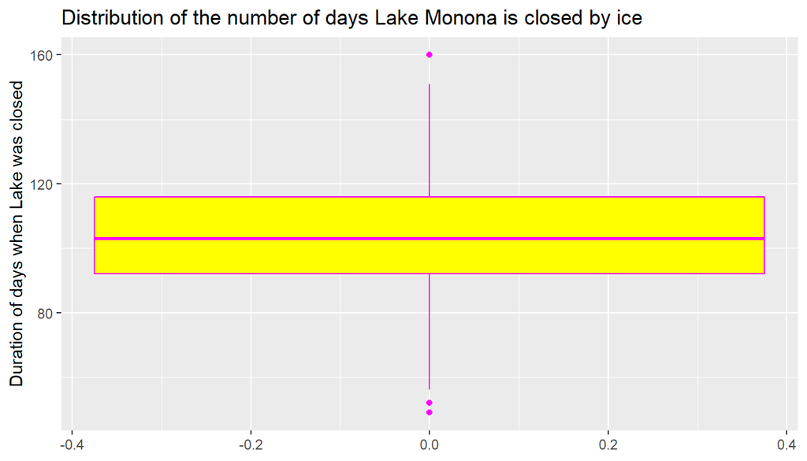

```r
ggplot(monona, aes(y=duration)) +
  geom_boxplot(fill = "yellow",
               color = "magenta") +
  ylab("Duration of days when Lake was closed") +
  ggtitle("Distribution of the number of days Lake Monona is closed by ice")
```

- What is the approximate median number of days Lake Monona has been closed with ice?

### Response

5. Write code to create a bar graph which displays the number of winters when the first freeze occured in each half-month period of time as recorded in the variable `ff_cat`. Choose your own colors if you do not like the default values. Make sure that your plot:
- has an informative title and subtitle
- has informative axis labels

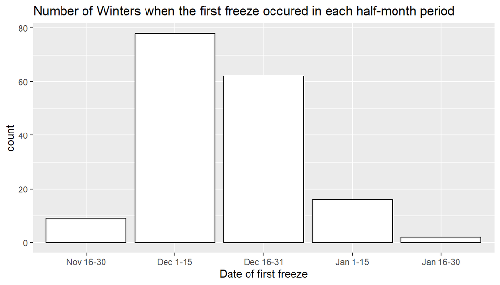

```r
ggplot(monona, aes(x = ff_cat)) +
  geom_bar(fill = "white", color = "black") +
  xlab("Date of first freeze") +
  ggtitle("Number of Winters when the first freeze occured in each half-month period")
```

6. Briefly explain why you needed to use the command `geom_bar()` and not `geom_col()` to make the plot in the previous problem.

###Response The bar plot is used when the count or bar height for a categorical variable has to be automatically determined based off of the given columns of the Dataframe. However, the Column plot is used when the count for each category is already available in the Data and is needed to be passed into the function.

7. The following chunk creates a scatter plot with `ff_x` on the x axis and `duration` on the y axis, with points colored by `period50`. The variable `ff_x` is a numerical coding of the first freeze date, counting days after June 30. For context, December 27 is 180 days after June 30. The default color scheme is changed to `viridis` which is friendlier to most people with various forms of color blindness. The command `geom_smooth(method = "lm", se = FALSE)` adds a straight line instead of a curve to the plot (that’s the `method = "lm"` argument) and because we specified `period50` as a grouping variable by mapping it to the color aesthetic, separate lines are added for each group.

Add code to add a plot title and to provide informative axis labels. Following examples from lecture notes, change the title of the color legend to say “Time Period” instead of “period50”.

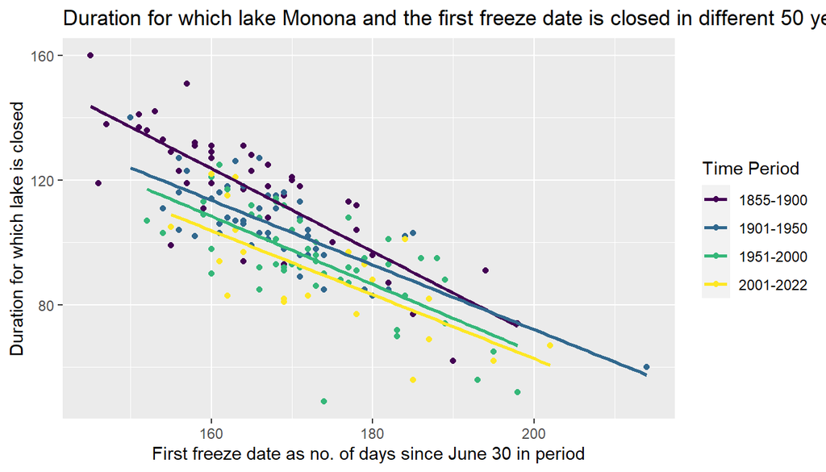

```r
ggplot(monona, aes(x = ff_x, y = duration, color = period50)) +
  geom_point() +
  geom_smooth(se = FALSE, method = "lm") +
  scale_color_viridis_d() +
  xlab("First freeze date as no. of days since June 30 in period") +
  ylab("Duration for which lake is closed") +
  ggtitle("Duration for which lake Monona and the first freeze date is closed in different 50 year periods") +
  guides(color = guide_legend("Time Period"))
```

After making the graph, suppose that the date of the first freeze in some year was December 27, which is 180 days after June 30. Based on an examination of the graph, briefly explain how your prediction of the total duration that Lake Monona is closed by ice would differ if the winter was in the 1870s versus the present?

### Response

8. The previous plot used color to distinguish which points were in each 50-year period of time. Write code to plot the same data in a scatter plot, but use a different facet (use `facet_wrap()`, following an example in the lecture notes) for each of the four different 50-year periods of time.

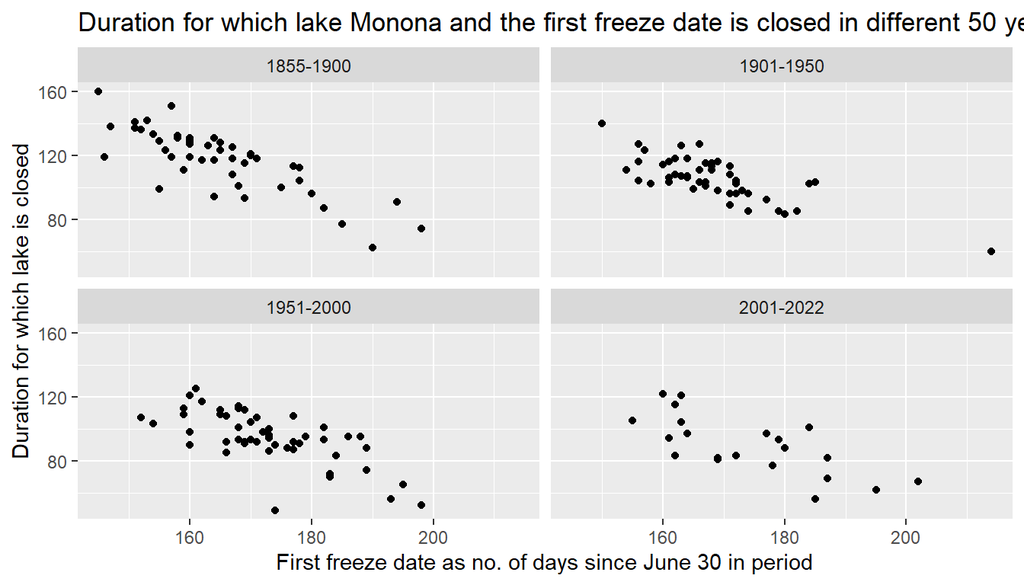

```r
ggplot(monona, aes(x=ff_x, y=duration)) +
  geom_point() +
  facet_wrap(vars(period50)) +
  xlab("First freeze date as no. of days since June 30 in period") +
  ylab("Duration for which lake is closed") +
  ggtitle("Duration for which lake Monona and the first freeze date is closed in different 50 year periods")
```

Does color or faceting make it easier to compare the relationship between first date of closing with ice and the total duration of the freeze among different 50-year time periods?

### Response

Faceting makes it easier to compare the relationship between the first date of closing with ice and total duration of the freeze among the different 50 year time periods since the data is less cluttered contributing to the clarity of analysis.